# gradient_boosting_regression

1. Practice Predicting NBA Salary. Download the data at: https://bryantstats.github.io/math460/python/nba_salary.csv
2. Import the data and drop all the missing values
3. Set the input (X) and output (y) (Use df.columns to see all the columns to easier copy/paste). Split the data into 60% training and 40% testing (No need to do 1.3 and 1.4 as all variables are numeric and have correct types)
4. Train an gradient boosting with 200 n_estimators and .1 learning_rare. What is testing Rsquared of the gradient boosting?
5. What is the most important variable according to the above gradient boosting model?
6. Find an gradient boosting (try a few different of n_estimators and learning_rate) that have a higher testing Rsquared than the above gradient boosting. What is the n_estimators and learning of this gradient boosting?
1. Import the data and drop all the missing values

```python
# Importing libraries
import pandas as pd
import numpy as np
from sklearn import tree
from sklearn import metrics
```

```python
# Importing data:
df = pd.read_csv('nba_salary.csv')
df.isna().sum()
```

```
Salary             0
NBA_DraftNumber    0
Age                0
G                  0
MP                 0
PER                0
TS%                2
3PAr               2
FTr                2
ORB%               0
DRB%               0
TRB%               0
AST%               0
STL%               0
BLK%               0
TOV%               2
USG%               0
OWS                0
DWS                0
WS                 0
WS/48              0
OBPM               0
DBPM               0
BPM                0
VORP               0
dtype: int64
```

```python
# Removing missing values from all columns in the dataframe.
df = df.dropna()
df.isna().sum()
```

```
Salary             0
NBA_DraftNumber    0
Age                0
G                  0
MP                 0
PER                0
TS%                0
3PAr               0
FTr                0
ORB%               0
DRB%               0
TRB%               0
AST%               0
STL%               0
BLK%               0
TOV%               0
USG%               0
OWS                0
DWS                0
WS                 0
WS/48              0
OBPM               0
DBPM               0
BPM                0
VORP               0
dtype: int64
```

1. Set the input (X) and output (y) (Use df.columns to see all the columns to easier copy/paste). Split the data into 60% training and 40% testing (No need to do 1.3 and 1.4 as all variables are numeric and have correct types)

```python
# Assign input variables
X = df.loc[:,['Age','PER','USG%','WS', 'TS%']]

# Assign target variable.
y = df['Salary']
```

1. Train an gradient boosting with 200 n_estimators and .1 learning_rare. What is testing Rsquared of the gradient boosting?

```python
# Splitting the data into 40% testing and 60% training.
np.random.seed(42)
from sklearn.model_selection import train_test_split
x_train,x_test,y_train,y_test=train_test_split(X,y,test_size=0.4)
```

```python
# Creating the gradient boosting model with n_estimators set to 200 and the learning rate set to 0.1
np.random.seed(42)
from sklearn.ensemble import GradientBoostingRegressor
r1 = GradientBoostingRegressor(n_estimators=200, learning_rate=0.1)
r1.fit(x_train, y_train)

# Rsquared
from sklearn.metrics import r2_score
print('Rsquared on Testing: ', r2_score(y_test, r1.predict(x_test)))
```

```
Rsquared on Testing:  0.34054776809702425
```

The R-Squared statistic on testing has been evaluated at ~0.3405.

1. What is the most important variable according to the above gradient boosting model?

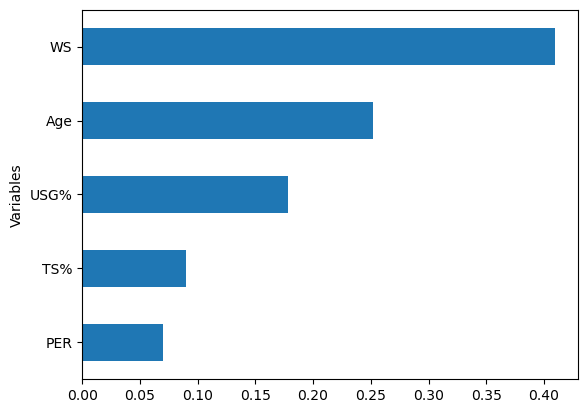

```python
# Plotting the variable importance from the gradient boosting model.

import warnings
warnings.filterwarnings('ignore')

sorted_idx = (-r1.feature_importances_).argsort()

feature_importance = pd.DataFrame({'Variables':x_train.columns[sorted_idx], 'Importance':r1.feature_importances_[sorted_idx]})
df = feature_importance[:10]
df.sort_values('Importance',inplace=True)

df.plot(kind='barh',y='Importance',x='Variables', legend=False)
```

According to the gradient boosting model, the most important variable when it comes to predicting salary is `WS` (winshares).

1. Find an gradient boosting (try a few different of n_estimators and learning_rate) that have a higher testing Rsquared than the above gradient boosting. What is the n_estimators and learning of this gradient boosting?

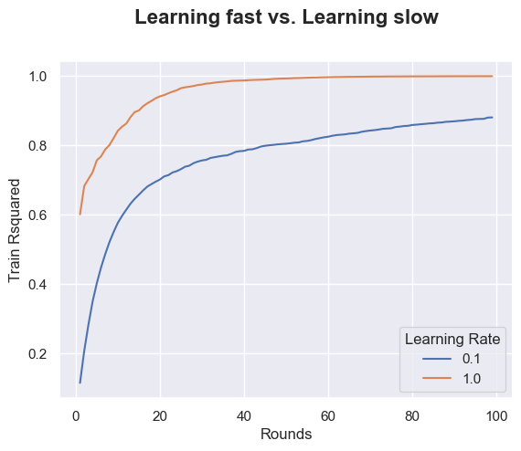

```python
# Plot the Training R-Squared of gradient boosting with n_estimators running from n1 to n2 and two learning rates l1 and l2.
np.random.seed(42)
n1 = 1
n2 = 100
l1 = .1
l2 = 1

ac = pd.DataFrame([], columns=list(['Rounds','Learning Rate','Testing Rsquared']))

for rs in range(n1, n2):
    for lr in [l1, l2]:
        boost = GradientBoostingRegressor(n_estimators=rs, learning_rate=lr)
        boost.fit(x_train,y_train)

        ac = pd.concat([ac, pd.DataFrame([[rs, lr, boost.score(x_train, y_train)]],
                                    columns=list(['Rounds','Learning Rate','Train Rsquared']))],
                       ignore_index=True)


import seaborn as sns; sns.set()
import matplotlib.pyplot as plt
ax = sns.lineplot(x="Rounds", y="Train Rsquared", hue =ac['Learning Rate'].astype('category'),data=ac)
ax.text(x=0.5, y=1.1, s='Learning fast vs. Learning slow', fontsize=16, weight='bold', ha='center', va='bottom', transform=ax.transAxes)
```

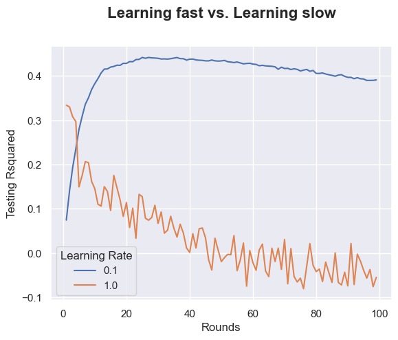

```python
# Plot the Testing R-Squared of gradient boosting with n_estimators running from n1 to n2 and two learning rates l1 and l2.
np.random.seed(42)
n1 = 1
n2 = 100
l1 = .1
l2 = 1

ac = pd.DataFrame([], columns=list(['Rounds','Learning Rate','Testing Rsquared']))

for rs in range(n1, n2):
    for lr in [l1, l2]:
        boost = GradientBoostingRegressor(n_estimators=rs, learning_rate=lr)
        boost.fit(x_train,y_train)

        ac = pd.concat([ac, pd.DataFrame([[rs, lr, boost.score(x_test, y_test)]],
                                    columns=list(['Rounds','Learning Rate','Testing Rsquared']))],
                       ignore_index=True)


import seaborn as sns; sns.set()
import matplotlib.pyplot as plt
ax = sns.lineplot(x="Rounds", y="Testing Rsquared", hue =ac['Learning Rate'].astype('category'),data=ac)
ax.text(x=0.5, y=1.1, s='Learning fast vs. Learning slow', fontsize=16, weight='bold', ha='center', va='bottom', transform=ax.transAxes)
```

```python
# Creating the the improved gradient boosting model with n_estimators set to 35 and the learning rate set to 0.1
np.random.seed(42)
from sklearn.ensemble import GradientBoostingRegressor
r1 = GradientBoostingRegressor(n_estimators=35, learning_rate=0.1)
r1.fit(x_train, y_train)

# Rsquared
from sklearn.metrics import r2_score
print('Rsquared on Testing: ', r2_score(y_test, r1.predict(x_test)))
```

```
Rsquared on Testing:  0.44081350702030153
```

The final R-Squared on Testing has been evaluated at ~ 0.4408